# STAT 440: Homework Assignment #3

Due: Thursday, Feb. 20 at 11:59pm on Canvas

Some of these exercises call for writing code. Please use R, and turn in your code along with your written work and any plots you are asked to produce. Just as you strive for clarity in your writing of language, try to write R code that is easy to read, in the sense that a knowledgeable user of R would be able to understand it easily.

You *may* choose to use LaTeX for your mathematics writing in your homework, in which case I recommend R Markdown as an easy way to combine text, mathematics, R code, and R output. But this is not required; you may choose to format your work however you find convenient, as long as you upload your assignment to Canvas as a single pdf document.

## Exercise 1

*This question is taken directly from the midterm exam for STAT 440 in FA 2023. The purpose of this question is to give you some practice with the style of questions you can expect on an exam.*

Let $X_1, \ldots, X_n$ be an i.i.d. random sample where each $X_i$ has the density function $g(x)= 4\exp\{-4(x-5)\} I\{x>5\}$.

Now suppose that $Z$ denotes a standard normal random variable. [The standard normal density function was provided on the front page of the midterm exam in FA 2023.] We wish to approximate the probability $P(Z > 5)$ using importance sampling. This probability may be expressed as follows:
$$P(Z > 5) = \int_5^\infty \phi(x)\,dx.$$
The importance sampling approximation should take the form of a sample mean, $(1/n) \sum_{i=1}^n s(X_i)$, for some function $s(X_i)$.

Derive the correct form of $s(X_i)$ and explain your work.

### Answer

Then we can apply importance sampling, which states that we can multiply and divide by another density function that is easy to sample from distribution that is also heavier tailed than the standard normal model. If we do not select a distribution that is heavier tailed than the standard normal, it could lead to infinite variance in our approximation. We know that our function g(x) is heavier tailed than the normal model because the exponential part of g(x) has a linear x-term instead of the quadratic x-term in the normal model, so the normal model will decay faster than g.

We are given that $P(X>5)=\int_5^\infty \phi(x)dx \approx \frac1n\sum_{i=1}^n s(X_i)$. So we need to derive $s(X_i)$

From Importance Sampling, we know that: $I = \int \phi(x)dx = \int\phi(x)\frac{g(x)}{g(x)}dx = E_g[\frac{\phi(x)}{g(x)}] \approx \frac1n\sum_{i=1}^n\frac{\phi(x)}{g(x)}$

Now we get that $s(X_i) = \frac{\phi(x)}{g(x)}$, and we can just plug in out density functions in.

$s(x) = \frac{\frac1{\sqrt{2\pi}}e^{-\frac{x^2}{2}}}{4e^{-4(x-5)} I_{\{x>5\}}}I_{\{x>5\}} = \frac1{4\sqrt{2\pi}}e^{-\frac{x^2}{2}+4x-20}$

$s(X_i)=\frac1{4\sqrt{2\pi}}e^{-\frac{X_i^2}{2}+4X_i-20}$

## Exercise 2

*This question is taken directly from the final exam for STAT 440 in FA 2023. The purpose of this question is to give you some practice with the style of questions you can expect on an exam.*

These questions are based on the `Auto` dataset from the `ISLR2` package in `R`.

For simple linear regression of miles per gallon (`mpg`) on year, obtain a permutation-based p-value for $H_0 : \beta_1 = 0$ using the Statkey screenshot below. Make sure you notice that the value of the estimated slope ($\hat{\beta_1}$) is provided above the “Original Sample” plot.

[figure not shown]

Figure: Statkey screenshot

### Answer

We can see from the screenshot that the slope of the linear regression is 0.581 so $\hat{\beta_1} = 0.581$

Our null hypothesis is that the slope is 0. We also get that we have 2000 samples were generated. The p-value is the probability of observing a value as extreme or more extreme than the observed value. Our Alternative hypothesis is $H_A: \hat\beta_1 \ne 0$, so this will be a two sided hypothesis test. We know that this is the alternative hypothesis because whenever we test coefficients in a regression model, we are testing whether the $\beta$ is significant to the model or not; if it is not significant it is 0, otherwise it is not 0 so it is meaningful.

This means we need to count the amount of dots that are to the left of -0.581 and to the right of 0.581. In this example, the plot is only shows points between -0.15 and 0.15, so we can assume that there are 0 points on either side of our boundary. This makes the pvalue essentially 0. This is extremely strong evidence against the null hypothesis, so the slope of the model is not 0.

## Exercise 3

While discussing the Week 03b notes in class, we coded an approximation to $P(Z>t)$, for a standard normal variable $Z$ and the extreme value $t=10$, using importance sampling:

```r
set.seed(440) # Make results exactly reproducible
# Sample from N(10, 1) as the proposal distribution:
X <- rnorm(1e4, mean=10)
# Now calculate the sample mean of h(X)f(X)/g(X) for appropriate h, f, and g:
mean((X>10) * dnorm(X) / dnorm(X-10))
```

```
## [1] 7.477867e-24
```

**Part (a)** This technique does not work for $t=100$, and even `pnorm` can’t directly evaluate $P(Z>100)$, since it is too close to zero for the current implementation of `R` to handle. However, `pnorm` will easily return the logarithm of $P(Z>100)$ as follows:

```r
pnorm(100, lower.tail = FALSE, log.p = TRUE)
```

```
## [1] -5005.524
```

To use Monte Carlo methods to approximate $\log P(Z>100)$, first, type in the function called `lmean` from the Week 03b notes. This function takes as an argument a vector of logarithms, then calculates the log of the mean of the original (non-logged) values.

Try applying `lmean` in a straightforward fashion: First, generate a new `X` vector from $N(100,1)$. What happens when you attempt `lmean((X>100) * log(dnorm(X) / dnorm(X-100)))`? Why?

**Part (b)** Fix the failure in part (a) by writing code that produces a reasonable Monte Carlo estimate of $\log P(Z>100)$ using the `lmean` function.

**Hints:** In R, the logarithm of zero is `-Inf`, and it might therefore seem problematic to use `lmean` with any zeros, but in fact `lmean` can handle some zeros with no problem. Here’s an example:

```r
y <- c(0, 0, 0, 1, 1, 1) # log of mean should be log(1/2)
lmean(log(y))
```

```
## [1] -0.6931472
```

The problem with part (a) is that some of the zeros are truly zeros, because they’re created by the `(X>100)` indicator, whereas some are merely “computer math” zeros because `R` can’t handle numbers that small. In short, you cannot reliably get the actual logarithm of `dnorm(X)` using `log(dnorm(X))`. You’ll need to come up with an alternative, and there are a couple of simple possibilities.

**Part (c)** In class, we used two different importance sampling ideas to approximate $P(X>10)$. The first is in part (a). The other used a shifted standard exponential proposal distribution, as follows:

```r
set.seed(440) # Make results exactly reproducible
# Sample from Exp(1) shifted by +10 as the proposal distribution:
X <- 10 + rexp(1e4)
# Now calculate the sample mean of h(X)f(X)/g(X) for appropriate h, f, and g:
mean((X>10) * dnorm(X) / dexp(X-10))
```

```
## [1] 7.736476e-24
```

One nice aspect of this method is that the final line of code makes very clear how the numerator is the integrand we’re trying to approximate and the denominator is the density of the simulated random variables.

Similar to part (b), use `lmean` to approximate $\log P(Z>100)$ using importance sampling with a shifted exponential proposal distribution.

### Answer

**Part (a)**

```r
lmean = function(lx) { #copy pasted from the notes
m = max(lx)
return(m + log(mean(exp(lx-m))))
}
```

Now we will attempt to use the new function to find P(Z>100)

```r
set.seed(440)

X <-rnorm(1e4,mean=100)

lmean((X>100) * log(dnorm(X) / dnorm(X-100)))
```

```
## [1] NaN
```

Running this code results in “Not a Number”. This is because the number that we are trying to compute is extremely small, so the computer cannot handle it.

Importance sampling says that $P(X>100) = E_g[I_{\{x>100\}}\log(\frac{\phi(x)}{g(x)})]$ in our code above, $\phi(x)$ is the density function for the standard normal model and $g(x)$ is the density function for $N(100,1)$. After plugging both functions in, we will get: $E_g[I_{\{x>100\}}\frac{\phi(x)}{g(x)}] = E_g[I_{\{x>100\}} \log(e^{\frac{200x-10000}2}) ] = E_g[I_{\{x>100\}}\frac{200x-10000}2]$

As we can see, for any values of x that are greater than 100, the values of x become extremely large. When computing the log mean from the function, we are exponentiating the already large number. This will result in an even larger number that the computer can’t handle, resulting in the program throwing the NaN error. Subtracting the max as the function does, wouldn’t help either. This is because an extremely large value for `lx` could result in a negative number of large magnitude to be in the exp function. This will result in an extremely small number for which R will throw NaN as well.

**Part (b)**

To solve this issue, we can cut out a middle step which is taking the log of the proportion of the normal distributions. I part a, we found what the fraction part of the importance sample reduces to. So instead of doing complex logs, fractions, and other computationally expensive procedures, we can just plug the weights of the proportion into the lmean function.

```r
weights <- (X > 100) * ((200 * X - 10000) / 2)
lmean(weights)
```

```
## [1] 5337.967
```

This solution avoid taking the log of the proportion of the densities, and then further exponentiation and another log in the lmean function.

**Part (c)**

```r
set.seed(440)

X <- 100 + rexp(1e4)
lmean(log((X>100) * dnorm(X) / dexp(X-100)))
```

```
## [1] NaN
```

This code results in NaN as well. So we need to expand the importance sample and reduce to just a weight like we did in the previous part.

$X \sim \mbox{expo}(\lambda = 1) + 100$ so then $g(x) = e^{-(x-100)}I_{\{x>100\}}$

$\frac{\phi(x)}{g(x)} = \frac{\frac1{\sqrt{2\pi}}e^{-\frac{x^2}{2}}}{e^{-(x-100)}I_{\{x>100\}}} = \frac1{2\pi I_{\{x>100\}}}e^{\frac{-x^2+2x-200}2}$

But since we are trying to find the log probability, we take the log of the proportion: $\log(\frac1{2\pi}e^{\frac{-x^2+2x-200}2}) = \frac{-x^2+2x-200}2 - \log(2\pi)$

Then we can use this as the weight for our importance sample.

```r
set.seed(440)

weights <- (X > 100) * (-X^2/2 + X - 100 - log(sqrt(2*pi)))

lmean(weights)
```

```
## [1] -5005.33
```

## Exercise 4

Go to the [Wikipedia page for antithetic variates](https://en.wikipedia.org/wiki/Antithetic_variates). Write code that reproduces the table given in “Example 2: Integral calculation”. Your values need not be exactly the same as those in the table, since they arise from a random simulation, but they should be close.

Just in case the Wikipedia page changes, there’s a screenshot in Canvas.

**Not required:** Since the example here is a toy problem where we know the exact value of the integral, it’s easy to compare the two estimates in the table with the true values. But the standard errors are also estimates, and it’s possible to calculate the true values they approximate, namely, $\sqrt{\mbox{Var}\hat{I}_n}$ for both versions of $\hat{I}_n$. Can you do this?

### Answer

According to the notes, the Antithetic Variates method for approximating an intergral is given by: $\frac1n \sum^n_{i=1}\frac12 [h(U_i)h(1-U_i)]$

```r
set.seed(440)
reps <- 750
n <- 1500

h <- function(x){
  1/(1+x)
}

simple <- 1:reps
antithetic <- 1:reps

for (i in 1:reps) {
  U <- runif(2*n)
  simple[i] <- mean(h(U))
  V <- U[1:n]
  antithetic[i] <- mean((h(V) + h(1-V))/2)
}

resultTable <- data.frame(
  Method = c("Simple", "Antithetic"),
  MeanOfEstimates = c(mean(simple), mean(antithetic)),
  SE = c(sd(simple), sd(antithetic)))

kable(resultTable)
```

| Method | MeanOfEstimates | SE |
| --- | --- | --- |
| Simple | 0.6932578 | 0.0025156 |
| Antithetic | 0.6930987 | 0.0006398 |

## Exercise 5

Consider the `chickwts` dataset in R. Weights in grams are recorded, for six groups of newly hatched chicks fed different supplements. There are six types of feed supplements.

```r
str(chickwts)
```

```
## 'data.frame':    71 obs. of  2 variables:
##  $ weight: num  179 160 136 227 217 168 108 124 143 140 ...
##  $ feed  : Factor w/ 6 levels "casein","horsebean",..: 2 2 2 2 2 2 2 2 2 2 ...
```

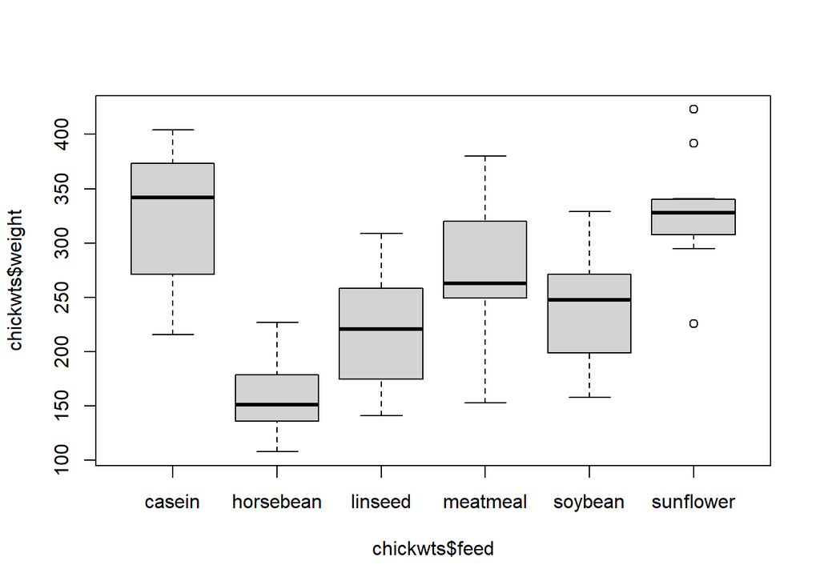

```r
boxplot(chickwts$weight~chickwts$feed)
```

We want to compare the distributions of weight for feed supplements.

**Part (a)** Use `R` to run the usual ANOVA to test whether two or more means of weight are equal. What is your F-statistic, p-value, and conclusion?

**Part (b)** Generate 10,000 permutation samples, get the F-statistic for each permuted sample, draw the histogram for these statistics, and superimpose the density function of an $F$ distribution with the correct df values from part (a). How close is the simulated null distribution to the $F$ distribution?

*Hint*: In `R`, for a continuous response vector `y` and a categorical predictor vector `cf`, you can obtain the $F$ statistic for the usual ANOVA test using `anova(aov(y ~ cf))$"F value"[1]`.

**Part (c)** Obtain the permutation-based p-value from part (b) and comment on what this tells you about this dataset.

### Answer

**Part (a)**

```r
Ftest <- anova(aov(data = chickwts, weight ~ feed))
Ftest
```

|  | Df | Sum Sq | Mean Sq | F value | Pr(>F) |
| --- | --- | --- | --- | --- | --- |
| feed | 5 | 231129.2 | 46225.832 | 15.3648 | 5.93642e-10 |
| Residuals | 65 | 195556.0 | 3008.554 | NA | NA |

From the output of the ANOVA test, we see that the F-statistic is 15.365 and the p-value is 5.936e-10 which is extremely small and close to 0. Since the pvalue is extremely small, there is significant evidence against the null hypothesis, which states that all the means of weights are the same. Rejecting the null hypothesis means that the average weights between the feeding groups are different from group to group.

**Part (B)**

For the ANOVA F test, we run 10000 ANOVA tests using shuffled labels and store the F-Statistic of each test in the Fstats vector

```r
set.seed(440)

weights <- chickwts$weight
feed_groups <- chickwts$feed

Fstats <- replicate(10000, {
  permuted_labels <- sample(feed_groups)  # permute feed labels

  anova(aov(weights ~ permuted_labels))$"F value"[1]  # Compute F-statistic
})
```

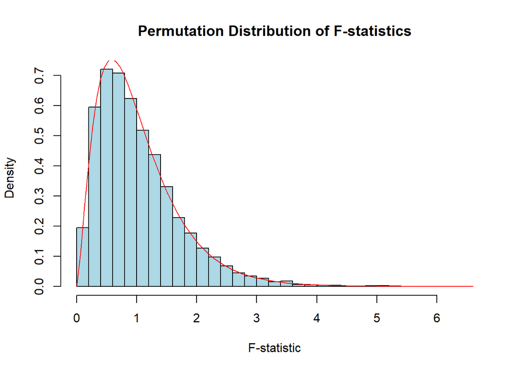

```r
hist(Fstats, probability = TRUE, breaks = 40,
     main = "Permutation Distribution of F-statistics",
     xlab = "F-statistic", col = "lightblue", border = "black")

# F-distribution
curve(df(x, df1 = Ftest$Df[1], df2 = Ftest$Df[2]), col = "red", add = TRUE)  # red curve for F-distribution
```

As we can see from the distribution of the F-statistics, it very closely follows the distribution for the F distribution under the null hypothesis.

**Part (c)**

```r
p_value <- mean(Fstats >= Ftest$`F value`[1])
p_value
```

```
## [1] 0
```

The Pvalue that we obtained from our sample is 0. This means that there are no F values in the Fstats vector that are as extreme or more extreme than the observed F statistic of 15.3648. Because of this, we will reject the null hypothesis. This is further proof that the average weights of the chicks between the feeding groups are different to eachother.